# NP AMR analyses

Sunheng Kaing & Nicholas Croucher

2026-05-04

# Functions

```r
compute_pairwise_distances <- function(df) {

  # Create all pairwise combinations of rows (upper triangle, no self-pairs)
  tidyr::expand_grid(
    i = seq_len(nrow(df)),
    j = seq_len(nrow(df))
  ) |>
    filter(i < j) |>
    mutate(
      # Sample identifiers for each pair
      sample_i = df$Sample_Name[i],
      sample_j = df$Sample_Name[j],

      # Cluster assignments for each pair
      cluster_i = df$Standard_Cluster[i],
      cluster_j = df$Standard_Cluster[j],

      # Euclidean distance: sqrt((x2 - x1)^2 + (y2 - y1)^2)
      euclidean_dist = sqrt(
        (df$tsne1D[j] - df$tsne1D[i])^2 +
        (df$tsne2D[j] - df$tsne2D[i])^2
      ),

      # Absolute size difference
      size_diff = abs(df$size[j] - df$size[i]),

      # Classify whether the pair shares a cluster
      same_cluster = case_when(
        cluster_i == "-1" | cluster_j == "-1" ~ "Unassigned",
        cluster_i == cluster_j               ~ "Same cluster",
        TRUE                                 ~ "Different cluster"
      )
    ) |>
    select(
      sample_i, sample_j,
      cluster_i, cluster_j,
      euclidean_dist,
      size_diff,
      same_cluster
    )
}

merge_clusters_by_distance <- function(df, dist_df, plasmid_dist_threshold, size_diff_threshold) {

  # --- Build edges from all pairs below both thresholds ---
  edges <- dist_df |>
    filter(
      euclidean_dist <= plasmid_dist_threshold & size_diff <= size_diff_threshold
    ) |>
    select(sample_i, sample_j)

  # --- Build graph from all samples as vertices ---
  # Isolated points (no edges) are preserved as their own single-node component
  g <- graph_from_data_frame(
    d        = edges,
    vertices = df$Sample_Name,
    directed = FALSE
  )

  # --- Extract connected components ---
  components_df <- tibble(
    Sample_Name    = V(g)$name,
    merged_cluster = components(g)$membership
  )

  # --- Join back to original df ---
  df |>
    left_join(components_df, by = "Sample_Name")
}

associate_resistance_plasmids <- function(m_df, amr_cols = NULL, plasmid_cols = NULL) {

  plasmid_res_df <-
    m_df %>%
      pivot_longer(cols = dplyr::any_of(amr_cols),
                   names_to = "Resistance gene",
                   values_to = "Resistance gene presence") %>%
      pivot_longer(
        cols = dplyr::any_of(plasmid_cols),
        names_to = "Plasmid",
        values_to = "Plasmid presence") %>%
      dplyr::select(id,
                    `Resistance gene`,
                    `Resistance gene presence`,
                    Plasmid,
                    `Plasmid presence`)


  # Step 2: Count bacteria with each plasmid (denominator)
  total_plasmid <-
    plasmid_res_df  %>%
      dplyr::filter(`Plasmid presence` != "Absent") %>%
      dplyr::distinct(id, Plasmid) %>%
      dplyr::count(Plasmid, name = "total_bacteria_and_plasmid")

  # Step 3: Count bacteria with gene and plasmid (numerator)
  plasmid_gene_counts <-
    plasmid_res_df  %>%
      dplyr::filter(`Resistance gene presence` != "Absent" &
                    `Plasmid presence` != "Absent") %>%
      dplyr::distinct(id, `Resistance gene`, Plasmid) %>%
      dplyr::count(`Resistance gene`, Plasmid, name = "count_gene_plasmid")

  # Step 4: Join and compute proportion
  plasmid_resistance_prop_df <-
    plasmid_gene_counts %>%
      dplyr::left_join(total_plasmid, by = "Plasmid") %>%
      dplyr::mutate(total_bacteria_and_plasmid =
                      dplyr::if_else(is.na(total_bacteria_and_plasmid),
                                     0,
                                     total_bacteria_and_plasmid)
                    ) %>%
      dplyr::mutate(proportion = count_gene_plasmid / total_bacteria_and_plasmid) %>%
      tidyr::complete(`Resistance gene`,
                      Plasmid,
                      fill = list(total_bacteria_and_plasmid = 0,
                                  proportion = 0))

  return(plasmid_resistance_prop_df)
}

widen_amr_data <- function(amr_df) {

  amr_df %>%
    # Split into list column
    mutate(gene_list = str_split(AB_resistance, ",")) %>%
    # Clean whitespace
    mutate(gene_list = map(gene_list, str_trim)) %>%
    # Unnest to long format
    unnest(gene_list) %>%
    # Remove original column
    select(-AB_resistance) %>%
    # Add presence indicator
    mutate(present = "Present") %>%
    distinct() %>%
    # Pivot to wide format
    pivot_wider(
      names_from = gene_list,
      values_from = present,
      values_fill = "Absent"
    )

}

add_to_microreact <- function(df1,df2,absent_value = "") {

  df1 %>%
    dplyr::left_join(df2,
                     by = c("id"="npg_run_id")) %>%
    dplyr::mutate(across(everything(), ~ ifelse(is.na(.x), absent_value, .x))) %>%
    dplyr::select(where(~!all(.x==absent_value)))

}

make_cluster_freq_wide_species <- function(mcat_cluster_freq,
                                           species_col  = "Species",
                                           clusters_col = "Cluster",
                                           cohort_col   = "Cohort") {

  # Wide: rows = Cluster, columns = Cohort; one table per Species
  # We'll keep long by species + cluster, wide by cohort.
  mcat_cluster_freq_wide <- mcat_cluster_freq %>%
    dplyr::mutate(Cohort =
                    factor(Cohort,
                           levels = c(
                             "Drakenstein",
                             "Hampshire (early)",
                             "Hampshire (late)",
                             "Maela",
                             "Siem Reap"
                           )
                    )
                  ) %>%
    dplyr::arrange(rev(Cohort)) %>%
    select(
      !!sym(species_col),
      !!sym(clusters_col),
      !!sym(cohort_col),
      Frequency
    ) %>%
    pivot_wider(
      id_cols    = c(!!sym(species_col), !!sym(clusters_col)),
      names_from = !!sym(cohort_col),
      values_from = Frequency
    )

  mcat_cluster_freq_wide
}

make_pair_panel_species <- function(wide_df,
                                    species_name,
                                    cohort_x,   # x-axis cohort
                                    cohort_y,   # y-axis cohort
                                    point_colour) {
  df_pair <- wide_df %>%
    dplyr::filter(Species == species_name) %>%
    dplyr::select(Species, Cluster, dplyr::all_of(c(cohort_x, cohort_y))) %>%
    # keep clusters present in at least one of the two cohorts
    dplyr::filter(
      !(is.na(.data[[cohort_x]]) & is.na(.data[[cohort_y]]))
    ) %>%
    dplyr::mutate(
      !!cohort_x := tidyr::replace_na(.data[[cohort_x]], 0),
      !!cohort_y := tidyr::replace_na(.data[[cohort_y]], 0)
    )
```

```r
  n_pts <- nrow(df_pair)

  if (n_pts >= 2) {
    ct <- suppressWarnings(
      cor.test(df_pair[[cohort_x]],
               df_pair[[cohort_y]],
               method = "spearman",
               exact  = FALSE)
    )
    p_val <- ct$p.value
    p_lab <- paste0("p = ", formatC(p_val, format = "e", digits = 2))
  } else {
    p_lab <- "p = NA"
  }

  ggplot(df_pair, aes(x =.data[[cohort_x]], y =.data[[cohort_y]])) +
    geom_point(alpha = 0.6, size = 0.7, colour = point_colour) +
    geom_smooth(formula = y ~ x,
                method = "lm",
                se = FALSE,
                colour = "#FD6467",
                linewidth = 0.5) +
    # numeric labels: N and p
    annotate("text",
             x = -Inf, y = Inf,
             label = paste0("N = ", n_pts),
             hjust = -0.1, vjust = 1.5,
             size = 3) +
    annotate("text",
             x = Inf, y = Inf,
             label = p_lab,
             hjust = 1.1, vjust = 1.5,
             size = 3) +
    labs(x = NULL, y = NULL) +
    theme_minimal(base_size = 9) +
    theme(
      #axis.text.x  = element_blank(),
      #axis.text.y  = element_blank(),
      axis.ticks.x = element_blank(),
      axis.ticks.y = element_blank(),
      panel.grid   = element_line(colour = "grey90", linewidth = 0.2)
    )
}

make_diag_hist_panel <- function(wide_df,
                                 cohort,
                                 species1,
                                 species2,
                                 species_palette) {
  df_long <- wide_df %>%
    dplyr::filter(Species %in% c(species1, species2)) %>%
    dplyr::select(Species, Cluster, dplyr::all_of(cohort)) %>%
    dplyr::rename(Frequency = dplyr::all_of(cohort)) %>%
    dplyr::mutate(Frequency = tidyr::replace_na(Frequency, 0)) %>%
    dplyr::filter(Frequency > 0)   # remove 0-frequency strains

  ggplot(df_long, aes(x = Frequency, fill = Species)) +
    geom_histogram(position = "identity",
                   alpha    = 0.5,
                   bins     = 30,  # adjust as you like
                   colour   = NA) +
    scale_fill_manual(values = species_palette) +
    labs(x = NULL, y = NULL) +
    ylim(c(0,2000)) +
    theme_minimal(base_size = 9) +
    theme(
      legend.position = "none",
      #axis.text.x  = element_blank(),
      #axis.text.y  = element_blank(),
      axis.ticks.x = element_blank(),
      axis.ticks.y = element_blank(),
      panel.grid   = element_line(colour = "grey90", linewidth = 0.2)
    )
}

make_diag_rank_panel <- function(wide_df,
                                 cohort,
                                 species1,
                                 species2,
                                 species_palette) {
  df_long <- wide_df %>%
    dplyr::filter(Species %in% c(species1, species2)) %>%
    dplyr::select(Species, Cluster, dplyr::all_of(cohort)) %>%
    dplyr::rename(Frequency = dplyr::all_of(cohort)) %>%
    dplyr::mutate(Frequency = tidyr::replace_na(Frequency, 0)) %>%
    dplyr::filter(Frequency > 0)  # remove 0-frequency strains

  df_ranked <- df_long %>%
    dplyr::group_by(Species) %>%
    dplyr::arrange(dplyr::desc(Frequency),.by_group = TRUE) %>%
    dplyr::mutate(Rank = dplyr::row_number()) %>%
    dplyr::ungroup()

  ggplot(df_ranked, aes(x = Rank, y = Frequency, colour = Species)) +
    geom_point(alpha = 0.7, size = 0.7) +
    geom_line(alpha = 0.6, linewidth = 0.4) +
    scale_colour_manual(values = species_palette) +
    labs(x = NULL, y = NULL) +
    theme_minimal(base_size = 9) +
    theme(
      legend.position = "none",
      #axis.text.x  = element_blank(),
      #axis.text.y  = element_blank(),
      axis.ticks.x = element_blank(),
      axis.ticks.y = element_blank(),
      panel.grid   = element_line(colour = "grey90", linewidth = 0.2)
    )
}

plot_mcat_cluster_pairs_two_species <- function(mcat_strains_freq,
                                                species1,
                                                species2,
                                                species_palette = c(species1 = "steelblue",
                                                                    species2 = "darkorange"),
                                                drakenstein_name = "Drakenstein",
                                                hist_on_diagonal = FALSE) {

  wide_df <- make_cluster_freq_wide_species(mcat_strains_freq)

  all_cohorts <- setdiff(names(wide_df), c("Species", "Cluster"))

  # Columns: all cohorts (including Drakenstein)
  col_cohorts <- all_cohorts

  # Rows for main grid: all except Drakenstein
  row_cohorts <- setdiff(all_cohorts, drakenstein_name)

  n_rows_main <- length(row_cohorts)
  n_cols      <- length(col_cohorts)

  panels <- list()

  blank_panel <- ggplot() + theme_void()

  # Set diagonal plot function
  diag_plot <- make_diag_rank_panel
  if (hist_on_diagonal) {
    diag_plot <- make_diag_hist_panel
  }

  ## Main grid (rows = row_cohorts; cols = col_cohorts)
  for (row_idx in seq_len(n_rows_main)) {
    for (col_idx in seq_len(n_cols)) {
      cx <- col_cohorts[col_idx]
      cy <- row_cohorts[row_idx]

      if (cx == cy) {
        # Diagonal for non-Drakenstein cohorts
        p <- diag_plot(
          wide_df,
          cohort          = cx,
          species1        = species1,
          species2        = species2,
          species_palette = species_palette
        )
      } else if (match(cx, all_cohorts) > match(cy, all_cohorts)) {
        # Upper-right: species1
        p <- make_pair_panel_species(
          wide_df      = wide_df,
          species_name = species1,
          cohort_x     = cx,
          cohort_y     = cy,
          point_colour = species_palette[species1]
        )
      } else {
        # Lower-left: species2
        p <- make_pair_panel_species(
          wide_df      = wide_df,
          species_name = species2,
          cohort_x     = cx,
          cohort_y     = cy,
          point_colour = species_palette[species2]
        )
      }

      # Column labels on top row only
      if (row_idx == 1) {
        p <- p + ggtitle(cx) +
          theme(
            plot.title = element_text(hjust = 0.5, size = 10)
          )
      } else {
        p <- p + ggtitle(NULL)
      }
```

```r
      # Y-axis cohort labels on first column only
      if (col_idx == 1) {
        p <- p +
          labs(y = cy) +
          theme(
            axis.title.y = element_text(angle = 90, size = 9, vjust = 0.5)
          )
      } else {
        p <- p + labs(y = NULL)
      }

      # No x-axis labels anywhere
      p <- p + labs(x = NULL)

      panels[[length(panels) + 1]] <- p
    }
  }

  ## Extra bottom row: Drakenstein self-self at its column
  drak_col_idx <- match(drakenstein_name, col_cohorts)

  for (col_idx in seq_len(n_cols)) {
    cx <- col_cohorts[col_idx]

    if (!is.na(drak_col_idx) && col_idx == drak_col_idx) {
      # Drakenstein diagonal panel
      p <- diag_plot(
        wide_df,
        cohort          = drakenstein_name,
        species1        = species1,
        species2        = species2,
        species_palette = species_palette
      )
    } else {
      p <- blank_panel
    }

    # Bottom row: no x or y labels
    p <- p + ggtitle(NULL) + labs(x = NULL, y = NULL)

    panels[[length(panels) + 1]] <- p
  }

  patchwork::wrap_plots(panels, nrow = n_rows_main + 1, ncol = n_cols)
}

process_gene_frequencies <- function(df,m_df) {

   df %>%
      dplyr::filter(CDS != "" & !is.na(CDS)) %>%
      dplyr::select(Gene,npg_run_id) %>%
      dplyr::rename(id = npg_run_id) %>%
      dplyr::left_join(m_df %>%
                         dplyr::select(id,Cohort),
                       by = "id") %>%
    group_by(Cohort,
             Gene) %>%
    mutate(Strains_count = n_distinct(id)) %>%
    dplyr::ungroup() %>%
    group_by(Cohort) %>%
    mutate(Frequency = Strains_count / n_distinct(id)) %>%
    dplyr::ungroup() %>%
    dplyr::select(-id) %>%
    dplyr::distinct() %>%
    dplyr::filter(!is.na(Cohort)) %>%
    dplyr::rename(Cluster = Gene)

}

process_strain_frequencies <- function(df) {

   df %>%
    dplyr::mutate(Cluster = as.character(Cluster)) %>%
    group_by(Cohort,
             Cluster) %>%
    summarise(Strains_count = n_distinct(id),
              .groups = "drop") %>%
    dplyr::ungroup() %>%
    group_by(Cohort) %>%
    mutate(Frequency = Strains_count / sum(Strains_count)) %>%
    dplyr::ungroup()

}
```

# Load data from project

Import sample data from project

```r
parse_sample_file <- function(fn) {

  read.table(file = fn,
             sep = "\t",
             comment.char = "",
             header = TRUE)

}

process_annotation_file_names <- function(df) {

   df %>%
    dplyr::filter(file_type == "annotation") %>%
    dplyr::mutate(npg_run_id = gsub("(.)+/","",path)) %>%
    dplyr::mutate(annotation_file = paste0(stringr::str_sub(file_uuid, start = 1L, end = 6L),'_',npg_run_id)) %>%
    dplyr::mutate(npg_run_id = gsub(".gff","",npg_run_id)) %>%
    dplyr::select(-path)

}

process_assembly_file_names <- function(df) {

   df %>%
    dplyr::filter(file_type == "assembly") %>%
    dplyr::mutate(npg_run_id = gsub("(.)+/","",gsub("/velvet_assembly/contigs.fa","",gsub("/spades_assembly/contigs.fa","",path)))) %>%
    dplyr::mutate(assembly_file = paste0(stringr::str_sub(file_uuid, start = 1L, end = 6L),'_contigs.fa')) %>%
    dplyr::select(npg_run_id,assembly_file)

}

process_qc_file_names <- function(df) {

   df %>%
    dplyr::filter(file_type == "qc") %>%
    dplyr::mutate(npg_run_id = gsub("(.)+/","",gsub("/kraken.report","",path))) %>%
    dplyr::mutate(qc_file = paste0(stringr::str_sub(file_uuid, start = 1L, end = 6L),'_kraken.report')) %>%
    dplyr::select(npg_run_id,qc_file)

}

# Parse sample files
drak_info_df <-
  read.csv("./sample_data/Drakenstein_epi.csv") %>%
      dplyr::mutate(Year = as.numeric(Year)) %>%
      dplyr::left_join(
        read_csv("./sample_data/Drakenstein_accessions.csv"),
        by = c("Isolate"="run_accession")
        )
```

```r
info_df <-
  dplyr::bind_rows(
    parse_sample_file("./sample_data/6588_info.tsv") %>%
      dplyr::filter(!grepl("HiC_RMV",sample_supplier_name)) %>%
      dplyr::mutate(project = "6588"),
    parse_sample_file("./sample_data/6310_info.tsv") %>%
      dplyr::mutate(project = "6310"),
    drak_info_df %>%
      dplyr::mutate(name = Isolate,
                    sample_accession_number = sample_accession,
                    sample_common_name = "Moraxella catarrhalis",
                    project = "Drakenstein",
                    sample_supplier_name = Isolate
                    ) %>%
      dplyr::select(name,sample_accession_number,sample_common_name,project,sample_supplier_name)
    )

run_df <-
  dplyr::bind_rows(
    parse_sample_file("./sample_data/6588_runs.tsv") %>%
      dplyr::select(-name),
    parse_sample_file("./sample_data/6310_runs.tsv") %>%
      dplyr::select(-name)
    )

fn_6588 <- "./sample_data/6588_files.tsv"
fn_6310 <- "./sample_data/6310_files.tsv"
files_df <-
  dplyr::bind_rows(
    parse_sample_file(fn_6588) %>% process_annotation_file_names(),
    parse_sample_file(fn_6310) %>% process_annotation_file_names()
    ) %>% dplyr::left_join(
    dplyr::bind_rows(
      parse_sample_file(fn_6588) %>% process_assembly_file_names(),
      parse_sample_file(fn_6310) %>% process_assembly_file_names()
      ),
    by = c("npg_run_id")
    ) %>% dplyr::left_join(
    dplyr::bind_rows(
      parse_sample_file(fn_6588) %>% process_qc_file_names(),
      parse_sample_file(fn_6310) %>% process_qc_file_names()
      ),
    by = c("npg_run_id")
    )

epi_df <-
  dplyr::bind_rows(
    read.csv("./sample_data/Asian_isolate_data.csv") %>%
      dplyr::mutate(Description = gsub(" from nasopharyngeal swab","",Description)) %>%
      dplyr::mutate(project = "6588") %>%
      dplyr::mutate(Species = Description) %>%
      dplyr::mutate(Description = dplyr::if_else(Species == "Mixed bacteria","Mixed bacteria","Single isolate")),
    read.csv("./sample_data/Hampshire_isolate_data.csv") %>%
      dplyr::mutate(Cohort = Country) %>%
      dplyr::mutate(project = "6588") %>%
      dplyr::mutate(Description = "Single isolate"),
    read.csv("./sample_data/Global-Hinf-metadata-microreact.csv") %>%
      dplyr::filter(disease == "") %>%
      dplyr::select(id,country,Year) %>%
      dplyr::filter(country == "Maela") %>%
      dplyr::rename(Isolate = id,
                    Region = country) %>%
      dplyr::mutate(Sample = Isolate,
                    Region = "Maela",
                    Cohort = "Maela",
                    Country = "Thailand",
                    Species = "Haemophilus influenzae",
                    project = "6310",
                    Year = as.numeric(Year)) %>%
      dplyr::mutate(npg_run_id = gsub("(_.*?)_", "\\1#", Sample)) %>%
      dplyr::mutate(Description = "Single isolate"),
    drak_info_df %>%
      dplyr::mutate(Isolate = sample_accession) %>%
      dplyr::select(-sample_accession) %>%
      dplyr::mutate(Description = "Single isolate")
    ) %>%
  dplyr::mutate(join_col = dplyr::case_when(
    project == "6588" ~ Sample,
    Country == "South Africa" ~ Isolate,
    TRUE ~ npg_run_id)) %>%
  dplyr::select(-c(project,npg_run_id,Sample))

# Merge data
sample_df <-
  info_df %>%
    dplyr::left_join(run_df, by = c("sample_uuid")) %>%
    dplyr::left_join(files_df, by = c("npg_run_id")) %>%
    dplyr::mutate(npg_run_id = dplyr::if_else(project == "Drakenstein",
                                              sample_accession_number,
                                              npg_run_id)) %>%
    dplyr::mutate(join_col = dplyr::if_else(project == "6588",sample_donor_id,npg_run_id)) %>%
    dplyr::left_join(epi_df, by = c("join_col")) %>%
    dplyr::mutate(Isolate = dplyr::if_else(project == "6310",name,Isolate)
                  ) %>%
    dplyr::select(-join_col) %>%
    dplyr::filter(!is.na(Country)) %>%
    dplyr::mutate(Cohort = dplyr::if_else(Cohort == "Thailand","Maela",Cohort)) %>%
    dplyr::mutate(Cohort =
                    dplyr::case_when(
                      Cohort == "Maela" ~ "Maela",
                      Cohort == "Cambodia" ~ "Siem Reap",
                      Cohort == "Drakenstein" ~ "Drakenstein",
                      Cohort == "United Kingdom" & Year < 2014 ~ "Hampshire (early)",
                      Cohort == "United Kingdom" & Year > 2014 ~ "Hampshire (late)"
                      )
                  ) %>%
  dplyr::mutate(Year =
                  dplyr::case_when(
                    !is.na(Year) ~ as.numeric(as.character(Year)),
                    grepl("_08B",sample_supplier_name) ~ 2008,
                    grepl("_09B",sample_supplier_name) ~ 2009,
                    grepl("_10B",sample_supplier_name) ~ 2010,
                    grepl("STGG",sample_supplier_name) ~ 2009, # Unclear use mid-range
                    grepl("MISSING",sample_supplier_name) ~ 2009, # Unclear use mid-range
                    TRUE ~ NA_real_
                  )
                )

plot_plasmid_function <- function(fn, title_str = NULL) {

  if (is.null(title_str)) {
    title_str = fn
  }

  plasmid_tsv <-
    readr::read_tsv(paste0('./plasmid_annotations/',fn),
                    col_names = TRUE,skip = 5)

  ggplot(plasmid_tsv, aes(xmin = Start, xmax = Stop, y = `#Sequence Id`, fill = Gene)) +
  geom_gene_arrow() +
  facet_wrap(~ `#Sequence Id`, scales = "free", ncol = 1) +
  scale_fill_brewer(palette = "Set3") +
  ggtitle(title_str) +
  theme_genes()

}

species_palette <- c(
  "Haemophilus influenzae" = "#E6A0C4FF",
  "Moraxella catarrhalis" = "#C6CDF7FF",
  "Plate sweep" = "#7294D4FF",
  "Mixed bacteria" = "#7294D4FF",
  "Other" = "#D8A499FF",
  "Unknown" = "#D8A499FF"
)
```

# Analysis of short-read data

## Quality control of data and association with sample information

### Identify species with Kraken and Bracken

Analysis of the short reads used the `qc-short-read` pipeline (revision 103cba2a10; v1.0.2), which depends upon:

- fastqc (v0.12.1)
- multiqc (v1.19)
- kraken2 (v2.1.3)
- bracken (v2.8)

The results are stored for projects 6310 and 6588.

```bash
module load bsub.py
module load qc-short-read
cd 6310_qc
echo -en "ID\tR1\tR2\n" > 6310.manifest; for f in ./results/fastqs/*_1.fastq.gz; do BASENAME=`basename ${f}`; echo -en "${BASENAME%_1.fastq.gz}\t${f}\t${f%_1.fastq.gz}_2.fastq.gz\n"; done >> 6310.manifest
bsub.py -q oversubscribed 4 6310_qc_rerun qc-short-read --manifest_of_reads 6310.manifest --kraken2_db /data/pam/software/kraken2/standard/k2_standard_20250402 --read_len 150 --classification_level S --enable_building -ansi-log false
cd ../6588_qc
echo -en "ID\tR1\tR2\n" > 6588.manifest; for f in ./results/fastqs/*_1.fastq.gz; do BASENAME=`basename ${f}`; echo -en "${BASENAME%_1.fastq.gz}\t${f}\t${f%_1.fastq.gz}_2.fastq.gz\n"; done >> 6588.manifest
bsub.py -q oversubscribed 4 6588_qc_rerun qc-short-read --manifest_of_reads 6588.manifest --kraken2_db /data/pam/software/kraken2/standard/k2_standard_20250402 --read_len 150 --classification_level S --enable_building -ansi-log false
```

Download data from the Drachenstein study; results are available here:

```bash
cd DRAK_study
module load PaM/environment
module load qc-short-read
module load bsub.py

bsub.py -q oversubscribed 4 DRAK_qc qc-short-read --manifest_ena DRAK.manifest --accession_type run --kraken2_db /data/pam/software/kraken2/standard/k2_standard_20250402 --read_len 150 --classification_level S --enable_building -ansi-log false
# Re-run for 7 failed samples
bsub.py -q oversubscribed 4 DRAK_qc_rerun qc-short-read -r 1.0.2 --manifest_ena DRAK_rerun.manifest --accession_type run --kraken2_db /data/pam/software/kraken2/standard/k2_standard_20250402 --read_len 150 --classification_level S --enable_building -ansi-log false
```

This run failed for seven isolates, which were subsequently re-run.

### Assemble reads with SPAdes and unicycler

Analysis of the short reads used the `assembly-unicycler-short-read` pipeline (v1.2.5; commit 92464961e453d624e88e69da06670638fb90ede0), developed from the bacass pipeline (v2.5.0; https://zenodo.org/records/17378847), which depends upon:

- QUAST (v5.0.2)
- Unicycler (v0.5.1)
- SPAdes (v4.0.0)

The results are stored for projects 6310 and 6588.

```bash
git clone --recurse-submodules git@gitlab.internal.sanger.ac.uk:sanger-pathogens/pipelines/assembly_unicycler_short_read.git
cd assembly_unicycler_short_read
echo -en "ID,R1,R2\n" > 6310.manifest; for f in ../6310_qc/results/fastqs/*_1.fastq.gz; do BASENAME=`basename ${f}`; echo -en "${BASENAME},/data/pam/team284/nc3/scratch/NP_AMR/data/6310_qc/results/fastqs/${BASENAME},/data/pam/team284/nc3/scratch/NP_AMR/data/6310_qc/results/fastqs/${BASENAME%_1.fastq.gz}_2.fastq.gz\n"; done >> 6310.manifest
echo -en "ID,R1,R2\n" > 6588.manifest; for f in ../6588_qc/results/fastqs/*_1.fastq.gz; do BASENAME=`basename ${f}`; echo -en "${BASENAME},/data/pam/team284/nc3/scratch/NP_AMR/data/6588_qc/results/fastqs/${BASENAME},/data/pam/team284/nc3/scratch/NP_AMR/data/6588_qc/results/fastqs/${BASENAME%_1.fastq.gz}_2.fastq.gz\n"; done >> 6588.manifest
bsub -o 6310_output.o -e 6310_error.e -q oversubscribed -R "select[mem>4000] rusage[mem=4000]" -M4000 nextflow run . --manifest ./6310.manifest --outdir 6310_assemblies
bsub -o 6588_output.o -e 6588_error.e -q oversubscribed -R "select[mem>4000] rusage[mem=4000]" -M4000 nextflow run . --manifest ./6588.manifest --outdir 6588_assemblies
```

Assemble data from the Drachenstein study; results are available here:

```bash
cd DRAK_study
module load PaM/environment
module load qc-short-read
module load bsub.py

bsub -o drak_output.o -e drak_error.e -q oversubscribed -R "select[mem>4000] rusage[mem=4000]" -M4000 nextflow run . --manifest_ena /data/pam/team284/nc3/scratch/NP_AMR/data/DRAK_study/DRAK.manifest --accession_type run --outdir /data/pam/team284/nc3/scratch/NP_AMR/data/DRAK_study/assemblies
```

### Annotate assemblies with Bakta

The assemblies were annotated using Bakta (version 1.11.0).

```bash
module load bakta/1.11.0
declare -i N; N=1; for f in *.fa; do echo "bakta --db /data/pam/software/bakta/v6.0 --prefix ${f%.fa} --output ${f%.fa}_annotation --gram - --threads 4 ${f}" > bacta_job.${N}; chmod +x ./bacta_job.${N}; N=($N+1); done
bsub -n 4 -M 4000 -R 'select[mem>4000] rusage[mem=4000] span[hosts=1]' -o bakta.%I.o -e bakta.%I.e -J bakta_run[1-4473] ./bacta_job.\${LSB_JOBINDEX}
```

This was also run on the Drachenstein isolates, after 1427/1429 isolates were successfully downloaded and assembled:

```bash
module load bakta/1.11
declare -i N; N=1; for f in *.fa; do echo "bakta --db /data/pam/software/bakta/v6.0 --prefix ${f%.fa} --output ${f%.fa}_annotation --gram - --threads 4 ${f}" > bacta_job.${N}; chmod +x ./bacta_job.${N}; N=($N+1); done
bsub -n 4 -M 12000 -R 'select[mem>12000] rusage[mem=12000] span[hosts=1]' -o bakta.%I.o -e bakta.%I.e -J bakta_run[1-1427] ./bacta_job.\${LSB_JOBINDEX}
```

### Evaluate assemblies with Quast

Assembly statistics were calculated with Quast (version 5.0.2).

```r
# Parse assembly statistics
assembly_stats_df <-
  dplyr::bind_rows(
    read.table(file = "./sample_data/NP_quast_report.tsv",
             check.names = FALSE,
             comment.char = "",
             sep ="\t",
             header = TRUE),
    read.table(file = "./sample_data/Drakenstein_summary_quast_report.tsv",
             check.names = FALSE,
             comment.char = "",
             sep ="\t",
             header = TRUE) %>%
      dplyr::mutate(Assembly = gsub(".assembly","",Assembly))
  ) %>%
    dplyr::rename(npg_run_id = Assembly)
```

### Quality control parameters for genomic assemblies

We will use these two files to merge getting chronological data set.

```r
sample_assemblies_df <-
  right_join(as_tibble(assembly_stats_df),
             as_tibble(sample_df),
             by = "npg_run_id")

minimum_length <- 1725000
maximum_length <- 2250000
n50_threshold <- 80000
```

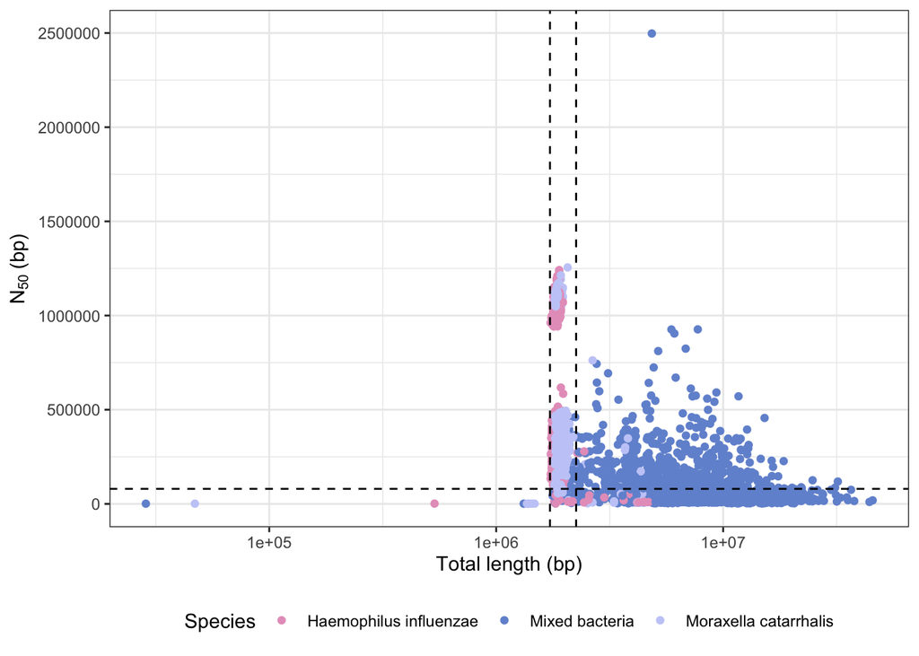

```r
ggplot(data = sample_assemblies_df) +
  geom_point(aes
             (x = `Total length`,
               y = N50,
               colour = Species)) +
  geom_hline(yintercept = n50_threshold, linetype = 2) +
  geom_vline(xintercept = c(minimum_length,
                            maximum_length), linetype = 2) +
  scale_colour_manual(values = species_palette) +
  scale_x_log10() +
  ylab(expression(N[50]~"(bp)")) +
  xlab("Total length (bp)") +
  theme(legend.position = "bottom")
```

These thresholds were used to remove low-quality assemblies:

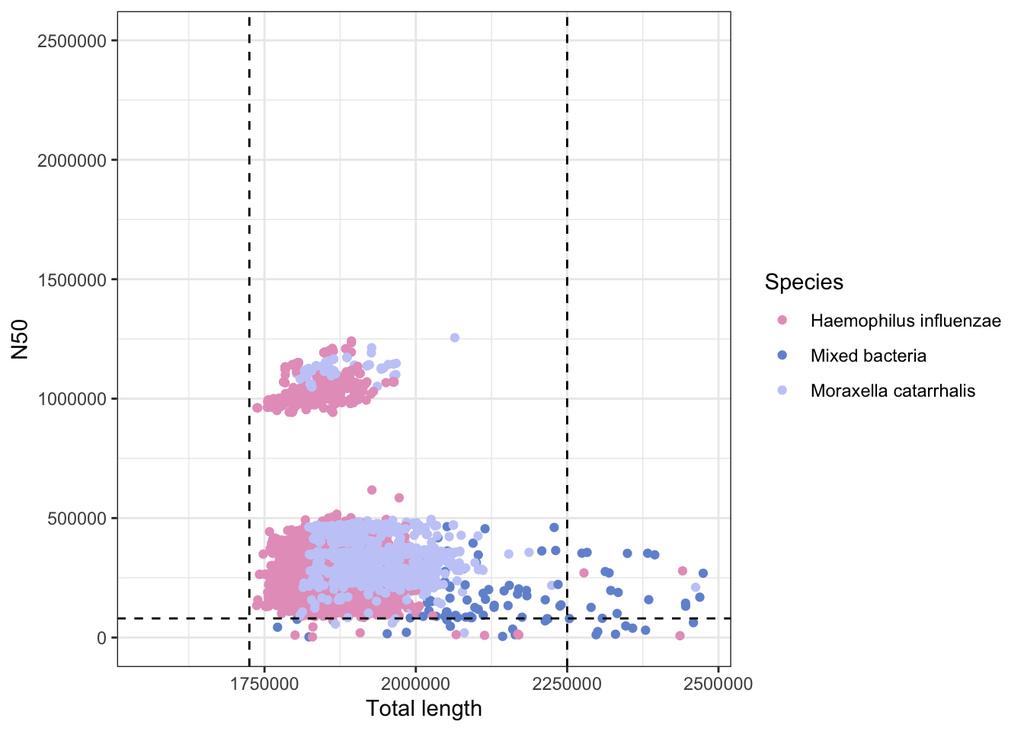

```r
high_quality_assemblies_df <-
  sample_assemblies_df %>%
  filter(N50 > n50_threshold &
           (`Total length` > minimum_length &
              `Total length` < maximum_length))

ggplot(data = sample_assemblies_df) +
  geom_point(aes
             (x = `Total length`,
               y = N50, colour = Species)) +
  geom_vline(xintercept = c(minimum_length,
                            maximum_length), linetype = 2) +
  geom_hline(yintercept = n50_threshold, linetype = 2) +
  scale_colour_manual(values = species_palette) +
  xlim(0.9*minimum_length,1.1*maximum_length)
```

### Identification of the species present in each sequence dataset

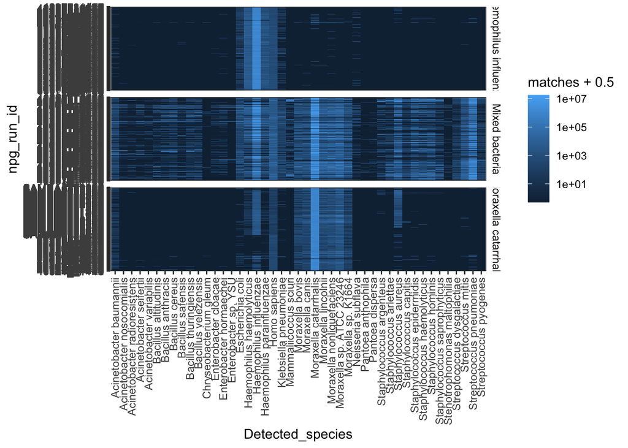

```r
parse_bracken <- function(fn) {

  read.table(file = gzfile(fn),
             check.names = FALSE,
             comment.char = "",
             sep ="\t",
             header = TRUE) %>%
    dplyr::filter(grepl("s__",Classification))
}

species_match_threshold = 10000000

species_abundance_df <-
  parse_bracken("./sample_data/6310_bracken_summary_report.tsv.gz") %>%
  dplyr::full_join(
    parse_bracken("./sample_data/6588_bracken_summary_report.tsv.gz"),
    by = "Classification"
  ) %>%
  dplyr::full_join(parse_bracken("./sample_data/Drakenstein_bracken_summary_report.tsv.gz"),
    by = "Classification"
  ) %>%
  dplyr::full_join(parse_bracken("./sample_data/Drakenstein_rerun_bracken_summary_report.tsv.gz"),
    by = "Classification"
  ) %>%
  dplyr::mutate(Classification = gsub("(.)*\\|s__","",Classification)) %>%
  tidyr::pivot_longer(cols = -Classification, names_to = "npg_run_id", values_to = "matches") %>%
  dplyr::rename(Species = Classification) %>%
  dplyr::mutate(matches = dplyr::if_else(is.na(matches),0,matches)) %>%
  dplyr::group_by(Species) %>%
  dplyr::mutate(Total = sum(matches)) %>%
  dplyr::ungroup() %>%
  dplyr::filter(Total > species_match_threshold)

# Join with sample information
species_sample_df <-
  species_abundance_df %>%
    dplyr::rename(Detected_species = Species) %>%
    dplyr::full_join(
      sample_df %>%
        dplyr::rename(Expected_species = Species),
      by = "npg_run_id"
    ) %>%
    dplyr::filter(!is.na(Country)) %>%  # Removing pre-filtered datasets, e.g. those dropped from HINTVAC
    # Reformat taxonomic labels
    dplyr::filter(!is.na(Detected_species)) %>%
    dplyr::mutate(Detected_species = gsub("_"," ",Detected_species)) %>%
    dplyr::mutate(Detected_genus = stringr::str_extract(Detected_species, '[A-Za-z]+'),
                  Expected_genus = stringr::str_extract(Expected_species, '[A-Za-z]+')
                  ) %>%
    # Calculate proportion of reads by species and genus
    dplyr::group_by(npg_run_id) %>%
    dplyr::mutate(species_read_count = matches,
                  read_count = sum(matches)
                  ) %>%
    dplyr::ungroup() %>%
    dplyr::group_by(npg_run_id,Detected_genus) %>%
    dplyr::mutate(genus_read_count = sum(matches)) %>%
    dplyr::ungroup() %>%
    dplyr::group_by(npg_run_id) %>%
    dplyr::mutate(Matching_species_proportion = dplyr::if_else(Detected_species == Expected_species,
                                                       species_read_count / read_count,
                                                       NA_real_),
                  Matching_genus_proportion = dplyr::if_else(Detected_genus == Expected_genus,
                                                       genus_read_count / read_count,
                                                       NA_real_)
                  ) %>%
    tidyr::fill(Matching_species_proportion, .direction = "updown") %>%
    tidyr::fill(Matching_genus_proportion, .direction = "updown") %>%
    dplyr::ungroup()

# Plot species matches
ggplot(species_sample_df,
       aes(x = Detected_species,
           y = npg_run_id,
           fill = matches+0.5)) +
  geom_tile() +
  facet_grid(Expected_species ~., scales = "free_y") +
  scale_fill_continuous(trans = "log10") +
  theme(axis.text.x = element_text(angle = 90, vjust = 0.5, hjust = 1))
```

### Identification of high-quality single isolate datasets

The single isolate sequences of *M. catarrhalis* and *H. influenzae* should contain relatively little sequence from other species - any such presence represents contamination.

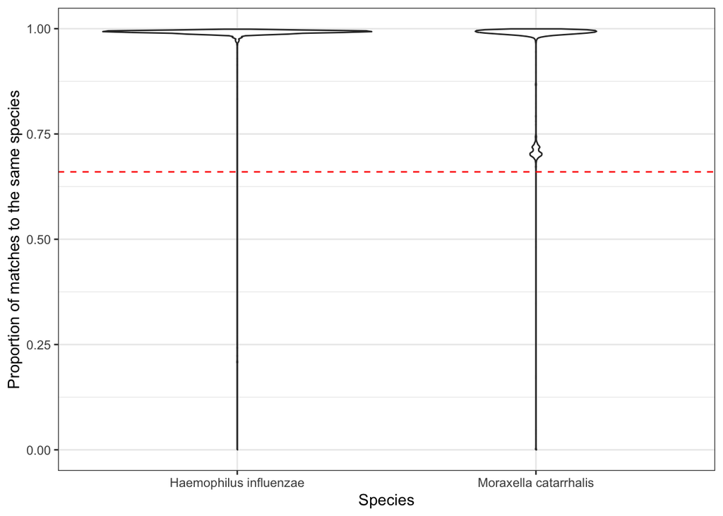

```r
species_proportion_threshold <- 0.66

ggplot(species_sample_df %>%
        dplyr::select(npg_run_id,
                      Description,
                      Expected_species,
                      Matching_species_proportion) %>%
        dplyr::distinct() %>%
        dplyr::filter(Description == "Single isolate"),
  aes(x = Expected_species,
      y = Matching_species_proportion)
  ) +
  geom_violin()+
  geom_hline(yintercept = species_proportion_threshold, linetype = "dashed", color = "red") +
  labs(x = "Species", y = "Proportion of matches to the same species")
```

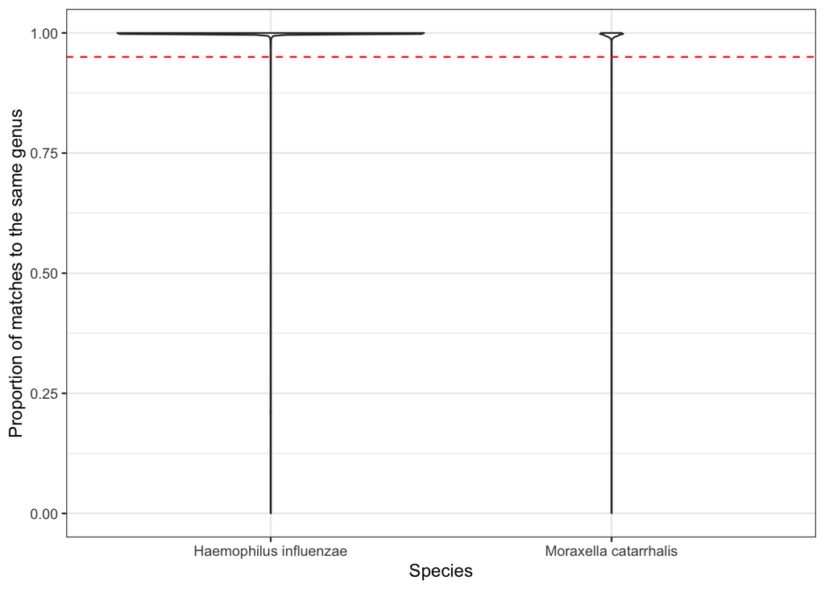

```r
genus_proportion_threshold <- 0.95

ggplot(species_sample_df %>%
        dplyr::select(npg_run_id,
                      Description,
                      Expected_species,
                      Matching_genus_proportion) %>%
        dplyr::distinct() %>%
        dplyr::filter(Description == "Single isolate"),
  aes(x = Expected_species,
      y = Matching_genus_proportion)
  ) +
  geom_violin()+
  geom_hline(yintercept = genus_proportion_threshold, linetype = "dashed", color = "red") +
  labs(x = "Species", y = "Proportion of matches to the same genus")
```

### Final filtering on sequence characteristics

We want to keep samples meeting the criteria:

```r
filtering_criteria_df <-
  sample_assemblies_df %>%
    dplyr::select(npg_run_id,Country,Year,`Total length`,N50) %>%
    dplyr::distinct() %>%
    dplyr::left_join(
      species_sample_df %>%
        dplyr::select(npg_run_id,
                      Description,
                      Expected_species,
                      Matching_species_proportion,
                      Matching_genus_proportion) %>%
        dplyr::distinct(),
      by = "npg_run_id"
    ) %>%
    dplyr::mutate(
      length_ok = `Total length` >= minimum_length &
                `Total length` <= maximum_length,
      n50_ok    = N50 >= n50_threshold,
      genus_ok  = Matching_genus_proportion >= genus_proportion_threshold,
      species_ok  = Matching_species_proportion >= species_proportion_threshold,
      all_ok    = length_ok & n50_ok & genus_ok & species_ok
    ) %>%
  dplyr::filter(Expected_species %in% c("Moraxella catarrhalis","Haemophilus influenzae"))

filtering_summary_df <-
  filtering_criteria_df %>%
    dplyr::group_by(Expected_species) %>%
    dplyr::summarise(
      `Number of genomes`    = n(),
      `Expected assembly length`   = sum(length_ok, na.rm = TRUE),
      `N50 above threshold`      = sum(n50_ok,    na.rm = TRUE),
      `Not contaminated`    = sum(genus_ok,  na.rm = TRUE),
      `Correct species`    = sum(species_ok,  na.rm = TRUE),
      `Passing all criteria`      = sum(all_ok,    na.rm = TRUE),.groups = "drop"
    )

kable(filtering_summary_df) %>%
  kable_styling(latex_options = "striped")
```

| Expected_species | Number of genomes | Expected assembly length | N50 above threshold | Not contaminated | Correct species | Passing all criteria |
| --- | --- | --- | --- | --- | --- | --- |
| Haemophilus influenzae | 4260 | 4234 | 4227 | 4233 | 4240 | 4219 |
| Moraxella catarrhalis | 2539 | 2479 | 2481 | 2483 | 2523 | 2462 |

### Output lists of high-quality single isolate sequences

Here we generate the final list of QC-passing *M. catarrhalis* isolates:

```r
Mcat_filter <-
  filtering_criteria_df %>%
    dplyr::filter(Expected_species == "Moraxella catarrhalis") %>%
    dplyr::filter(all_ok) %>%
    dplyr::select(npg_run_id) %>%
    dplyr::distinct()

write.table(Mcat_filter,
            file = "./sample_data/Mcat_QC_pass.csv",
            col.names = FALSE,
            row.names = FALSE,
            quote = FALSE)
```

Here we generate the final list of QC-passing *H. influenzae* isolates:

```r
Hflu_filter <-
  filtering_criteria_df %>%
    dplyr::filter(Expected_species == "Haemophilus influenzae") %>%
    dplyr::filter(all_ok) %>%
    dplyr::select(npg_run_id) %>%
    dplyr::distinct()

write.table(Hflu_filter,
            file = "./sample_data/Hflu_QC_pass.csv",
            col.names = FALSE,
            row.names = FALSE,
            quote = FALSE)
```

### Epidemiological characteristics of filtered single-isolate dataset

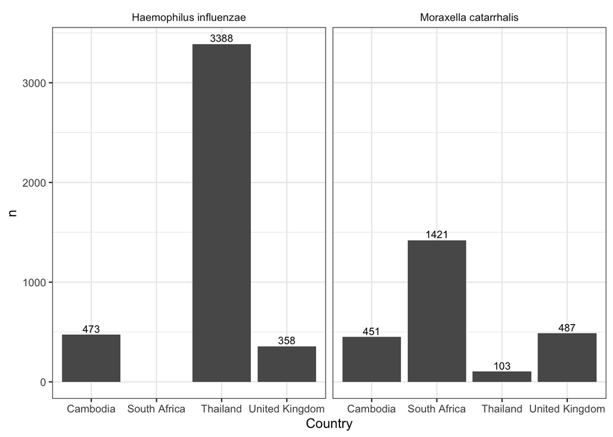

```r
ggplot(filtering_criteria_df %>%
         dplyr::filter(all_ok) %>%
         dplyr::group_by(Expected_species,Country) %>%
         dplyr::summarise(n = n_distinct(npg_run_id)) %>%
         dplyr::ungroup(),
       aes(x = Country,
           y = n)) +
  geom_bar(stat = "identity") +
  geom_text(
    aes(label = n),
    position = position_dodge(width = 0.9),
    vjust = -0.3, size = 3
    ) +
  facet_wrap(~Expected_species)
```

## Use PopPUNK to categorise isolates

### Definition of the *M. catarrhalis* PopPUNK scheme

The *M. catarrhalis* population can be divided into serosensitive and seroresistant isolates. The serosensitive isolates are associated with deeper branches than the seroresistant isolates. Therefore it is necessary to define separate PopPUNK schemes for these two types.

First, the distances were calculated for all the *M. catarrhalis* genomes using PopPUNK version 2.7.7:

```r
for f in $(cat Mcat_QC_pass.csv); do echo -en "${f}.fa\tfastas/${f}.fa\n"; done > Mcat_poppunk.in
poppunk --create-db --output Mcat_poppunk_db --r-files Mcat_poppunk.in --threads 24 --gpu-dist --min-k 13 --max-k 39
```

The distance distribution shows:

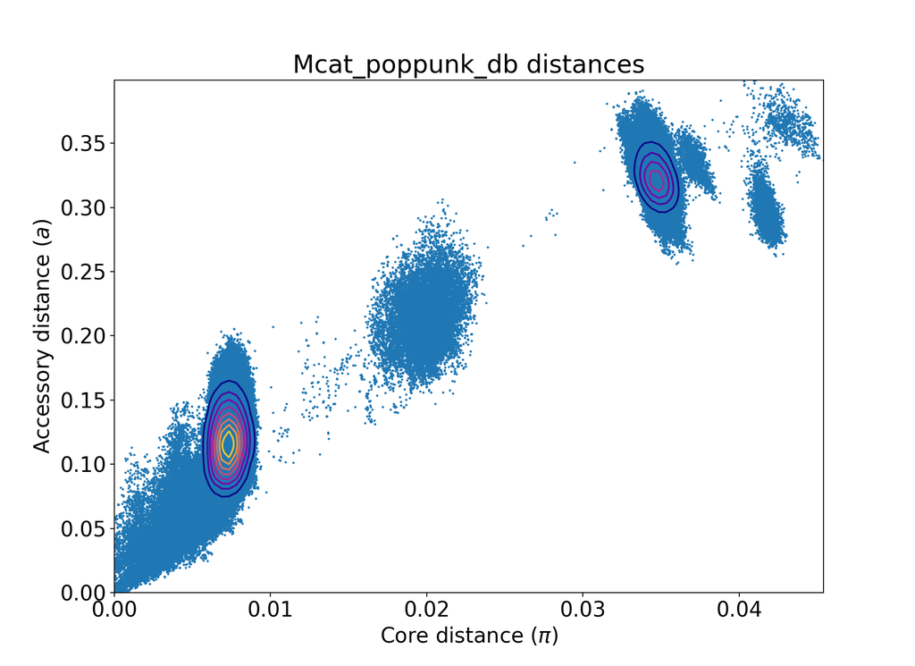

Pairwise distance distribution

An initial refinement was used to identify a boundary separating the serosensitive and seroresistant isolates. This required searching the region bounded by (0.025,0.25) and (0.0325,0.275):

```r
poppunk --fit-model dbscan --ref-db Mcat_poppunk_db --output Mcat_seroClassification_db  --threads 40
poppunk --fit-model refine --ref-db Mcat_poppunk_db --model-dir Mcat_seroClassification_db --output Mcat_seroClassification_db --threads 40 --manual-start Mcat_sero_classication.manual_start --score 2 --unconstrained
```

This results in a boundary:

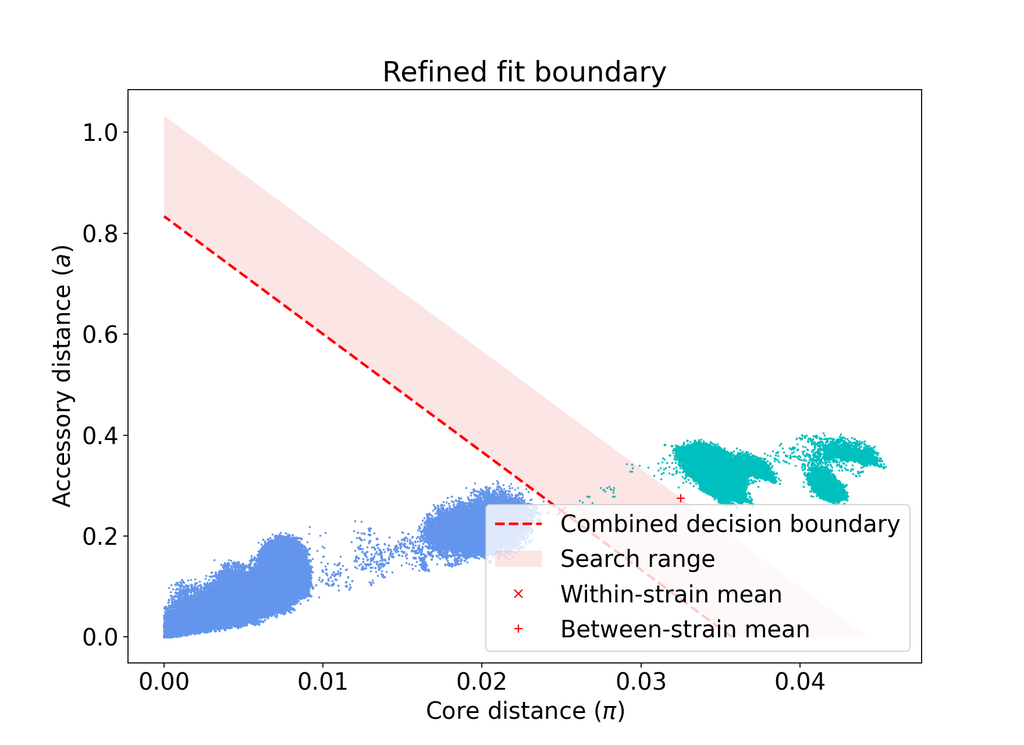

Boundary

This classification can be visualised:

```bash
poppunk_visualise --ref-db Mcat_poppunk_db --model-dir Mcat_seroClassification_db --microreact --output Mcat_seroClassification_viz --gpu-dist
```

These isolates can be viewed in [microreact](https://microreact.org/project/hQ9WcBim9Yspg9vEvVPWqr-moraxella-population-structure) - the file is available as Mcat_seroClassification_viz.microreact.

In accordance with [previous](https://www.microbiologyresearch.org/content/journal/mgen/10.1099/mgen.0.001488) [work](https://www.microbiologyresearch.org/content/journal/mgen/10.1099/mgen.0.000820), The isolates can therefore be classified as seroresistant (cluster 1), serosensitive (cluster 2), atypical cluster 1 (cluster 3), and atypical cluster 2 (cluster 4).

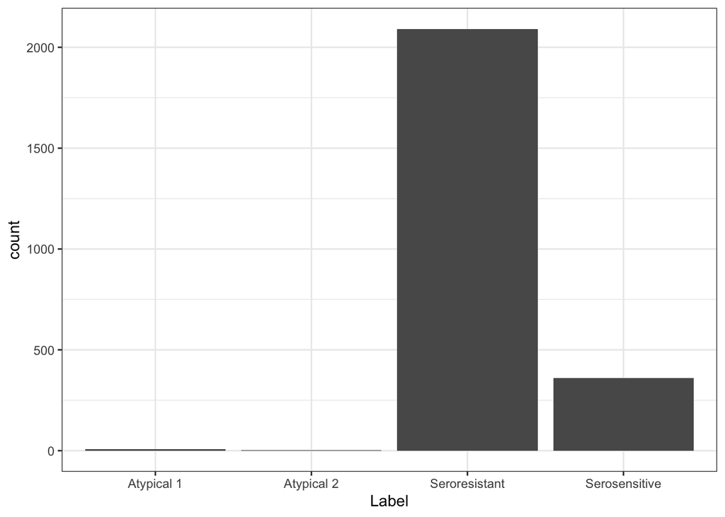

```r
cluster_labels = tibble(
  Cluster = 1:4,
  Label = c("Seroresistant","Serosensitive","Atypical 1","Atypical 2")
)

mcat_categorisation <-
  read.csv("./PopPUNK_analysis/Mcat_seroClassification_db_clusters.csv") %>%
    dplyr::left_join(cluster_labels, by = "Cluster")

mcat_non_seroResistant_list <-
  mcat_categorisation %>% dplyr::filter(Label != "Seroresistant") %>% dplyr::pull(Taxon)

mcat_non_seroSensitive_list <-
  mcat_categorisation %>% dplyr::filter(Label != "Serosensitive") %>% dplyr::pull(Taxon)

write.table(mcat_non_seroResistant_list,
            file = "./PopPUNK_analysis/Mcat_non_seroResistant.names",
            quote = FALSE,
            col.names = FALSE,
            row.names = FALSE)

write.table(mcat_non_seroSensitive_list,
            file = "./PopPUNK_analysis/Mcat_non_seroSensitive.names",
            quote = FALSE,
            col.names = FALSE,
            row.names = FALSE)

ggplot(mcat_categorisation,
       aes(x = Label)) +
  geom_bar()
```

Separate PopPUNK databases can be generated for the seroresistant and serosensitive isolates:

```bash
rm -rf Mcat_seroSensitive_db Mcat_seroResistant_db
# Copy the overall database for pruning
mkdir Mcat_seroSensitive_db
mkdir Mcat_seroResistant_db
for f in Mcat_poppunk_db/*; do
  g=`basename $f`;
  cp $f Mcat_seroSensitive_db/Mcat_seroSensitive_db${g#Mcat_poppunk_db};
  cp $f Mcat_seroResistant_db/Mcat_seroResistant_db${g#Mcat_poppunk_db};
done
# Prune the serosensitive database
poppunk --qc-db --ref-db Mcat_seroSensitive_db --remove-samples Mcat_non_seroSensitive.names --type-isolate SAMEA5130801_fa --max-a-dist 1.0  --max-pi-dist 1.0 --max-zero-dist 1.0 --length-sigma 100
# Prune the seroresistant database
poppunk --qc-db --ref-db Mcat_seroResistant_db --remove-samples Mcat_non_seroResistant.names --type-isolate SAMEA4622306_fa --max-a-dist 1.0  --max-pi-dist 1.0 --max-zero-dist 1.0  --length-sigma 100
```

First, a DBSCAN model can be fitted to the smaller set of serosensitive isolates:

```bash
poppunk --fit-model dbscan --ref-db Mcat_seroSensitive_db --output Mcat_seroSensitive_model_db --threads 24
```

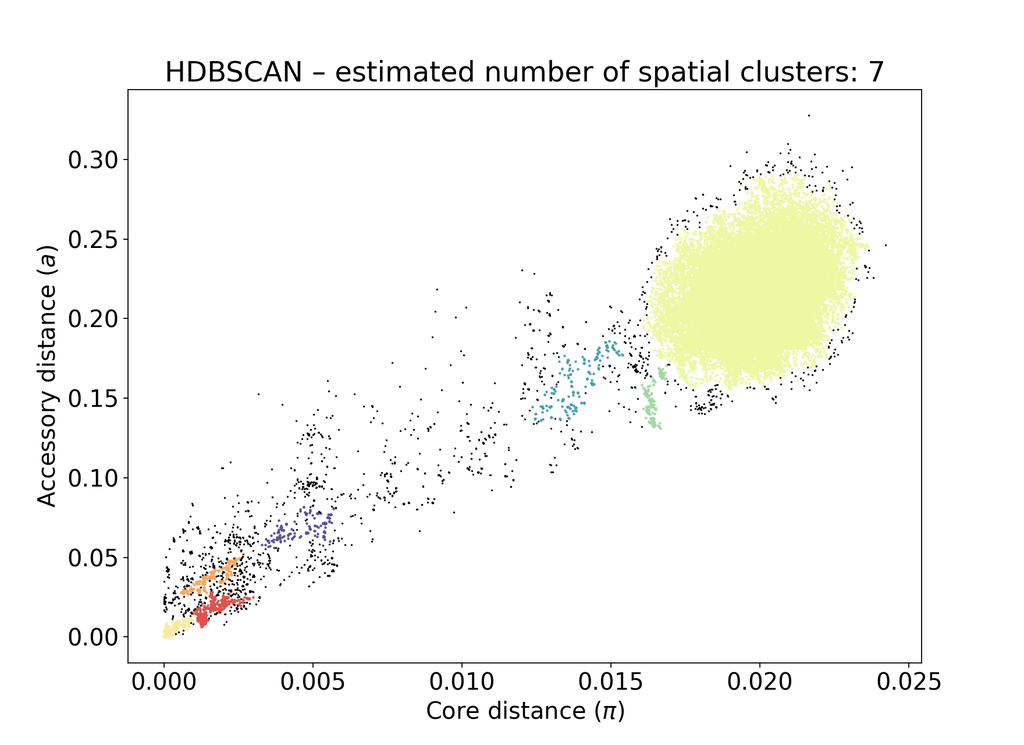

```bash
poppunk --fit-model refine --ref-db Mcat_seroSensitive_db --model-dir Mcat_seroSensitive_model_db --output Mcat_seroSensitive_refined_model_db --threads 48 --score 0 --manual-start Serosensitive.manual_start
```

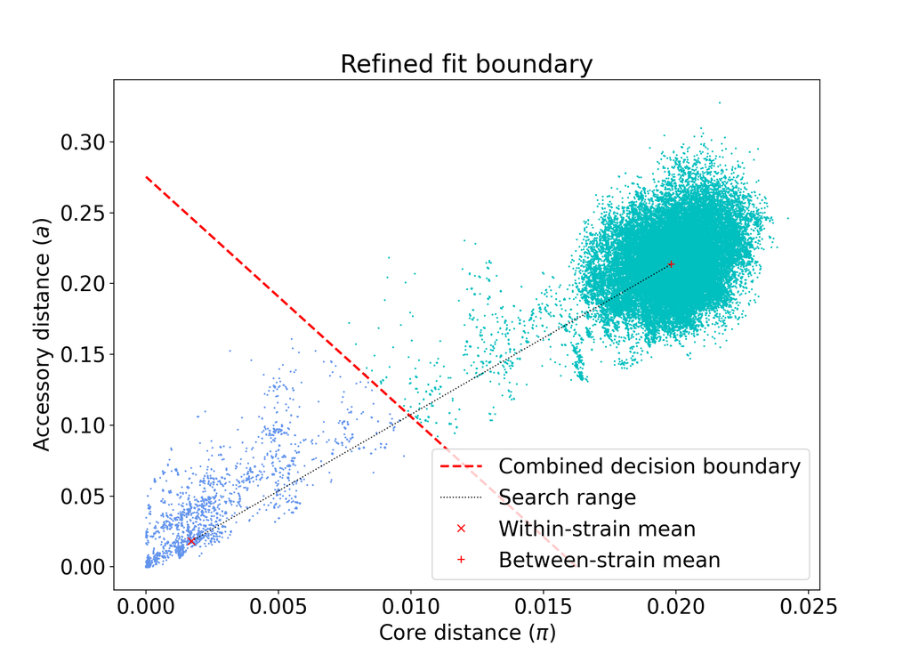

Refined fit to serosensitive isolates

The clustering was then visualised:

```bash
poppunk_visualise --ref-db Mcat_seroSensitive_db --model-dir Mcat_seroSensitive_refined_model_db --threads 1 --output Mcat_seroSensitive_viz --microreact
```

The output is available to view on [microreact](https://microreact.org/project/rpga9c9gmDfso7kugYhs8G-serosensitive-moraxella-poppunk) using the file.

A DBSCAN model can also be fitted to the seroresistant isolates:

```bash
poppunk --fit-model dbscan --ref-db Mcat_seroResistant_db --output Mcat_seroResistant_model_db
```

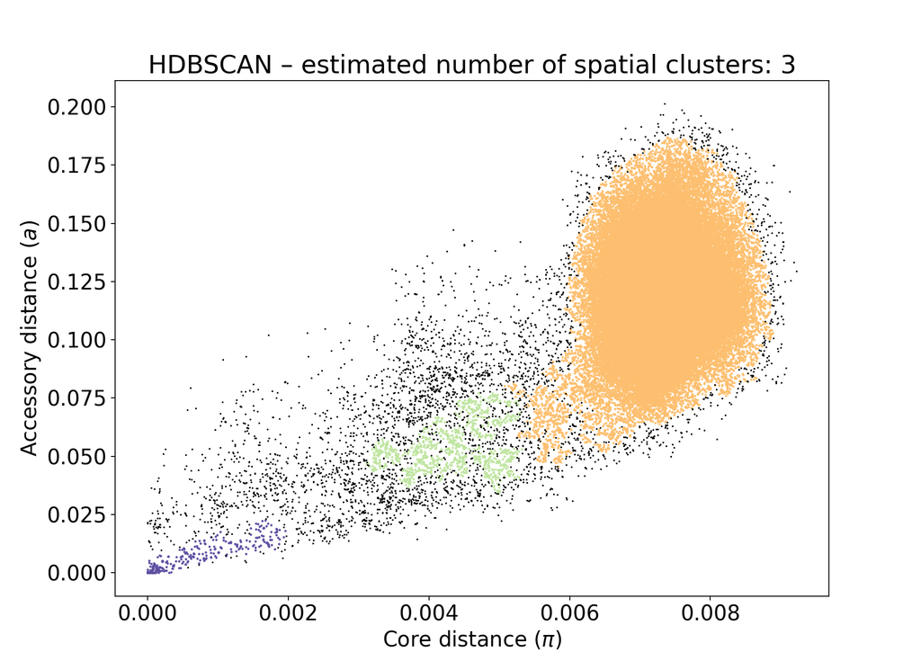

DBSCAN fit to seroresistant isolate

The distance distribution for the seroresistant isolates demonstrates the isolates are <1% divergent in the core genome, with ~12.5% divergence in the accessory genome.

The model can be refined for the seroresistant isolates using the same approach as for the serosensitive isolates. The DBSCAN cluster positions used to guide the refined fit were (0.06521943,0.03128192) for the within-strain distances, and (0.78877825,0.58528107) for the between-strain distances. The boundary defined by the within-strain distances was moved away from the origin by a negative shift of 20%, to make the fit analogous with the serosensitive fit:

```bash
poppunk --fit-model refine --ref-db Mcat_seroResistant_db --model-dir Mcat_seroResistant_model_db --output Mcat_seroResistant_refined_model_db --threads 48 --score 0 --manual-start Seroresistant.manual_start --neg-shift -0.2
```

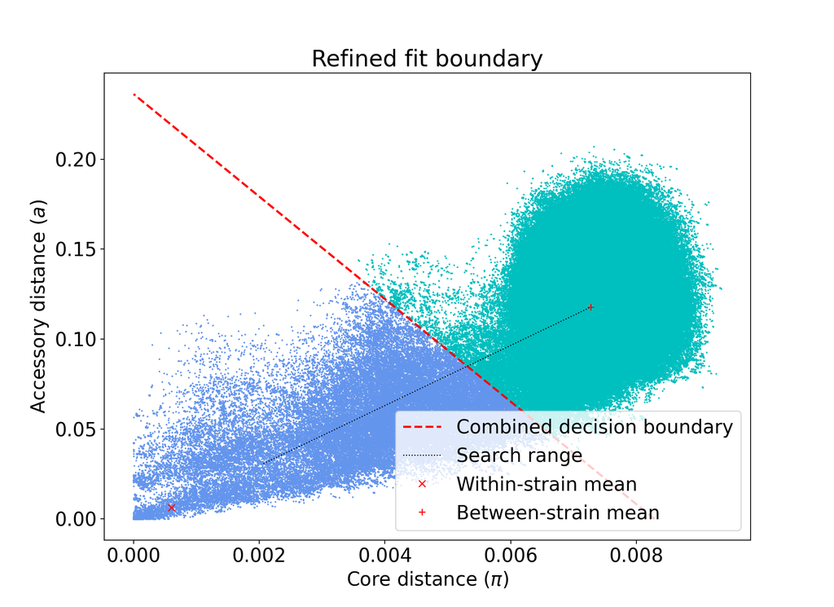

Refined fit to seroresistant isolates

The output can then be visualised, and the strains classified:

```bash
poppunk_visualise --ref-db Mcat_seroResistant_db --model-dir Mcat_seroResistant_refined_model_db --threads 1 --output Mcat_seroResistant_viz --microreact
```

The output is available to view on [microreact](https://microreact.org/project/cYSZ1g2Scstfbg1hVpoe7r-seroresistant-moraxella-poppunk) using the file.

Finally, we arrive at a classification of all *Moraxella catarrhalis* isolates:

```r
mcat_strains_df <-
  mcat_categorisation %>%
    dplyr::select(-Cluster) %>%
    dplyr::rename(Classification = Label) %>%
    dplyr::left_join(
      read_csv("./PopPUNK_analysis/Mcat_seroSensitive_refined_model_db_clusters.csv") %>%
        dplyr::rename(SerosensitiveCluster = Cluster) %>%
        dplyr::mutate(SerosensitiveCluster = paste0("Serosensitive_",SerosensitiveCluster)),
      by = "Taxon"
    ) %>%
    dplyr::left_join(
      read_csv("./PopPUNK_analysis/Mcat_seroResistant_refined_model_db_clusters.csv") %>%
        dplyr::rename(SeroresistantCluster = Cluster) %>%
        dplyr::mutate(SeroresistantCluster = paste0("Seroresistant_",SeroresistantCluster)),
      by = "Taxon"
    ) %>%
    dplyr::mutate(
      Cluster =
        dplyr::case_when(
          Classification == "Seroresistant" ~ SeroresistantCluster,
          Classification == "Serosensitive" ~ SerosensitiveCluster,
          TRUE ~ gsub(" ","_",Classification)
        )
    ) %>%
    dplyr::select(Taxon,Classification,Cluster)
# Check number of output isolates matches the number of input isolates
#if (nrow(Mcat_filter) != nrow(mcat_strains_df)) {
if (TRUE) {
  message(paste("Expected output:",nrow(Mcat_filter)))
  message(paste("Observed output:",nrow(mcat_strains_df)))
  #stop("Count mismatch between Mcat isolates input into, and output from, PopPUNK\n")
}
```

```
## Expected output: 2462
## Observed output: 2462
```